# Antecedent temperature experiment

## Respiration Results

**click to open**

Respiration measurements were taken daily during the incubation using a Li-850 bench top respiration unit. Below are the respiration rates for each sample, as well as the calculates accumulative respiration rates.linear models are also drawn in represented color, with 95% confidence interval.

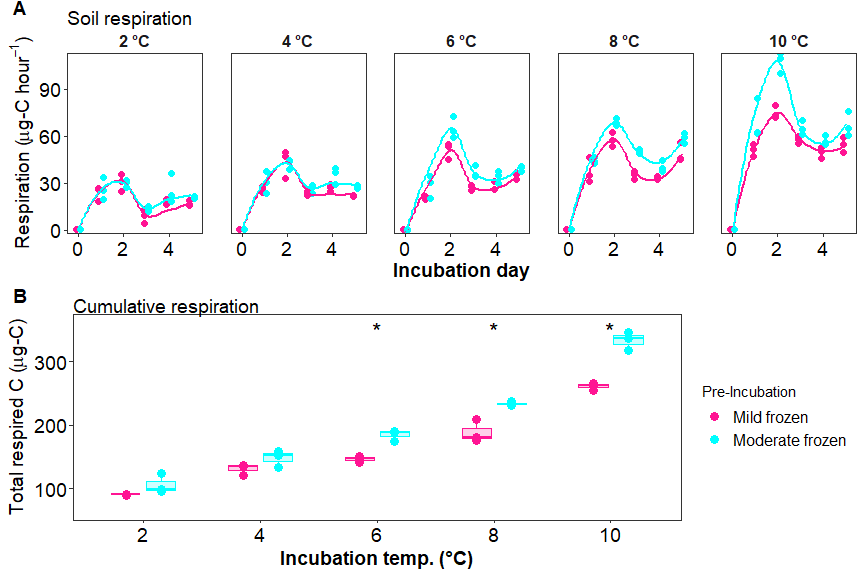

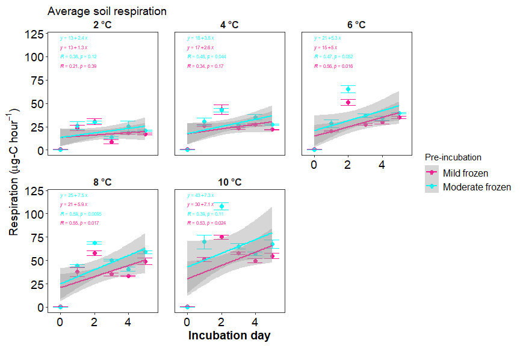

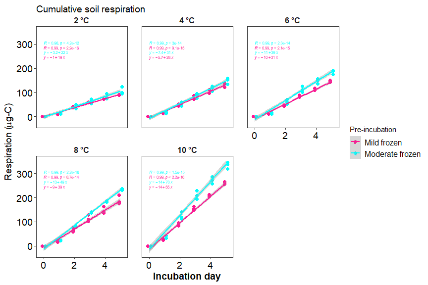

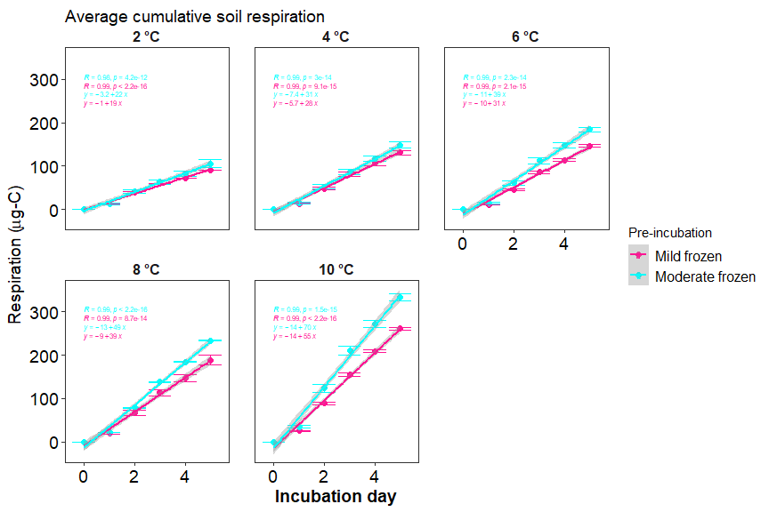

## Soil Nutrients

**click to open**

Soil K2SO4 extracts were utilized to measure ammonium, Nitrate, Total free primary amines, phosphate, Total reducing sugars. Below are the concentration data. An asterisks indicates a significant (p<= 0.05) difference in pre-incubation temperature.

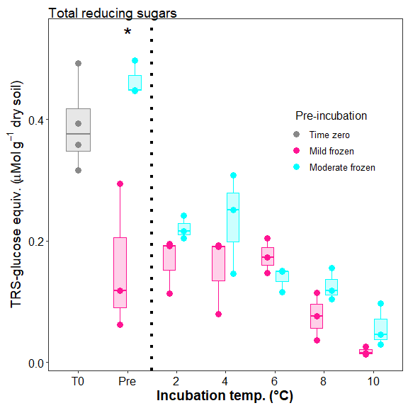

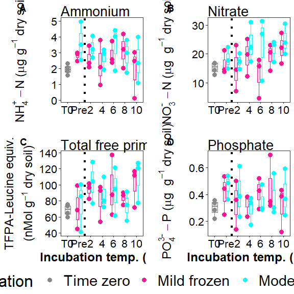

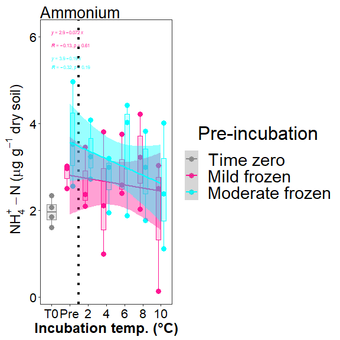

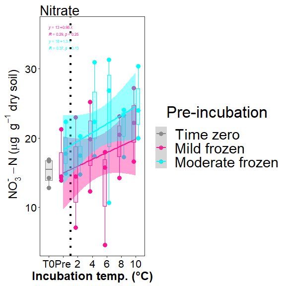

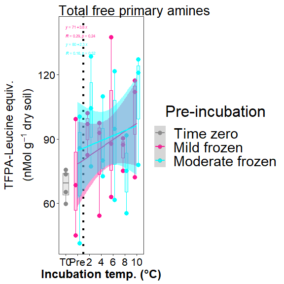

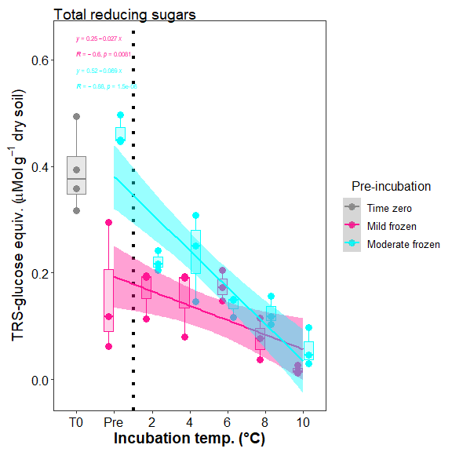

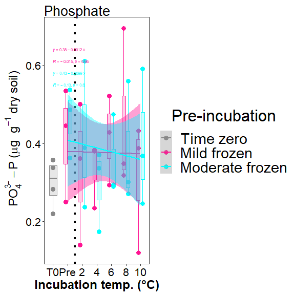

## Microbial Biomass

**click to open**

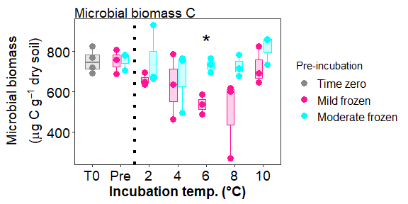

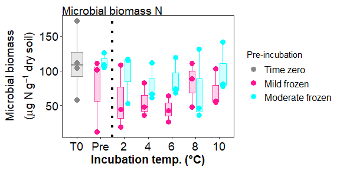

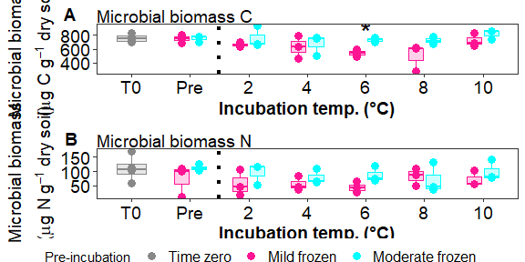

## Stats Table

**click to open**

```
## $`Respiration statistics: anova(lme(Res ~ JD2 + Inc_temp + pre_inc,random = ~1|Sample_ID))`
##
##
##                numDF   denDF      F-value     p-value
## ------------  ------  ------  -----------  ----------
## (Intercept)        1     149   673.355930   0.0000000
## JD2                1     149    40.135389   0.0000000
## Inc_temp           1      27    91.448720   0.0000000
## pre_inc            1      27     6.956082   0.0136884
##
## $diffres
##
##
## Table: Difference in cumulative respiration between pre incubation temperatures
##
##  Inc_temp         -6          -2       Diff
## ---------  ---------  ----------  ---------
##         2   105.8210    90.26896   15.55202
##         4   148.5354   131.09775   17.43764
##         6   184.5535   146.32651   38.22700
##         8   233.7851   188.78486   45.00021
##        10   333.6863   261.20783   72.47846
##
## $LastRES_aov
##             Df Sum Sq Mean Sq F value   Pr(>F)
## pre_inc      1  10682   10682   22.84 5.51e-05 ***
## Inc_temp     1 132694  132694  283.75 7.53e-16 ***
## Residuals   27  12627     468
## ---
## Signif. codes:  0 '***' 0.001 '**' 0.01 '*' 0.05 '.' 0.1 ' ' 1
##
## $`ANOVA Nutrients and Microbial biomass: aov(conc ~ pre_inc*Inc_temp)`
##
##
## Table: Extraction ANOVA results
##
## analyte   term                df          sumsq         meansq    statistic     p.value  asterisk
## --------  -----------------  ---  -------------  -------------  -----------  ----------  ---------
## FTN       pre_inc              2   1.374035e+04   6.870176e+03    6.4166775   0.0061033  *
## FTN       Inc_temp             5   4.117262e+03   8.234524e+02    0.7690965   0.5816130  NA
```

[output cut: 395 more lines]

```
## $all_aov4
##
##
## Table: Extraction ANOVA results microbial biomass
##
## analyte   term                df        sumsq       meansq   statistic     p.value  asterisk
## --------  -----------------  ---  -----------  -----------  ----------  ----------  ---------
## MBC       pre_inc              2   120213.484   60106.7422   5.1910967   0.0137863  *
## MBC       Inc_temp             5   137188.626   27437.7252   2.3696491   0.0712674  NA
## MBC       pre_inc:Inc_temp     5    50703.129   10140.6258   0.8757914   0.5126424  NA
## MBC       Residuals           23   266312.717   11578.8138          NA          NA  NA
## MBN       pre_inc              2     7126.838    3563.4189   2.8206592   0.0802510  NA
## MBN       Inc_temp             5     2074.324     414.8649   0.3283903   0.8906130  NA
## MBN       pre_inc:Inc_temp     5     3892.345     778.4691   0.6162048   0.6886524  NA
## MBN       Residuals           23    29056.553    1263.3284          NA          NA  NA
```

## Session Info

**Session Info**

Date run: 2024-05-30